# Validating some Beliefs about Income Bias

## Exploratory Data Analysis

Let’s explore the dataset and understand the patterns with the data before building any machine learning model.

### Hypothesis 1: People who are older earn more

The variable `age` is numeric, so we can check its distribution with respect to the `income` labels using a density plot:

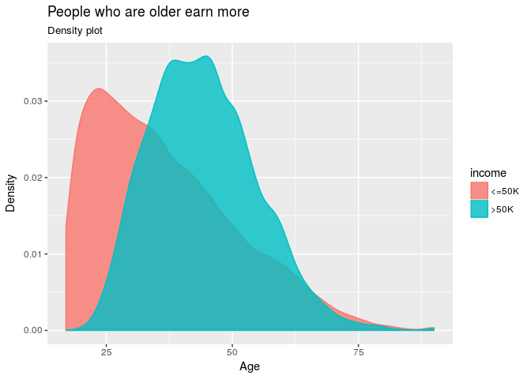

```r
ggplot(dataset, aes(x = age, color = income, fill = income)) +
   geom_density(alpha = 0.8) +
   labs(x = "Age", y = "Density", title = "People who are older earn more",
        subtitle = "Density plot")
```

Or a boxplot:

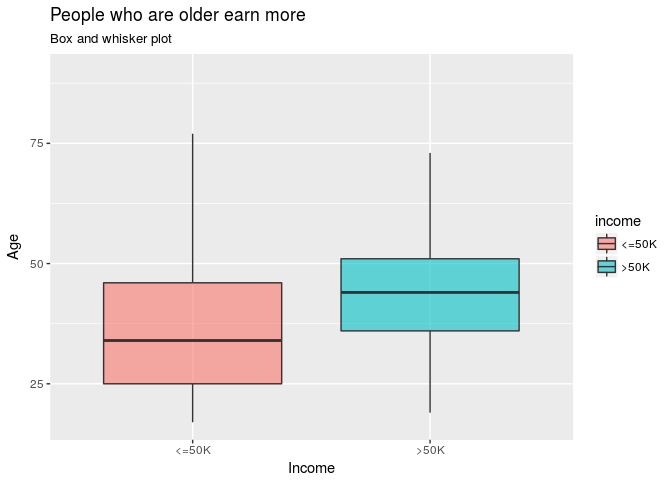

```r
ggplot(dataset, aes(x = income, y = age, fill = income)) +
   geom_boxplot(alpha = 0.6, outlier.shape = NA) +
   labs(x = "Income", y = "Age", title = "People who are older earn more",
        subtitle = "Box and whisker plot")
```

Now let’s estimate the central tendency for the `age` in both groups:

```r
dataset %>%
   dplyr::group_by(income) %>%
   dplyr::summarise(age = median(age))
```

```
## # A tibble: 2 × 2
##   income   age
##   <fctr> <dbl>
## 1  <=50K    34
## 2   >50K    44
```

So, people who earn above 50K tend to be aged around 44, while people who earn below 50K tend to be aged around 34.

### Hypothesis 2: Income bias based on working class

We can use a stacked bar chart to visualize the income class proportions for each working class, as follows:

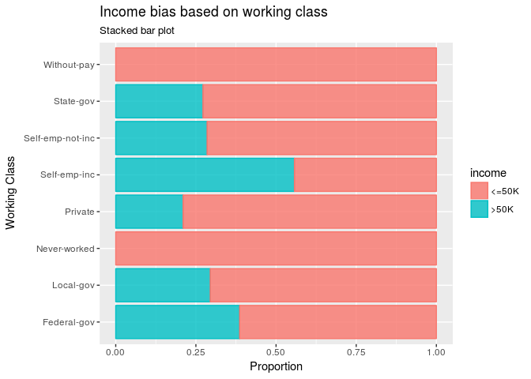

```r
ggplot(dataset, aes(x = workclass, fill = income, color = income)) +
   geom_bar(alpha = 0.8, position = "fill") +
   coord_flip() +
   labs(x = "Working Class", y = "Proportion", title = "Income bias based on working class",
        subtitle = "Stacked bar plot")
```

Now, to be more precise, let’s calculate the class proportions:

```r
prop.table(table(dataset$workclass, dataset$income), 1) * 100
```

```
##
##                        <=50K      >50K
##   Federal-gov       61.35417  38.64583
##   Local-gov         70.52078  29.47922
##   Never-worked     100.00000   0.00000
##   Private           78.99071  21.00929
##   Self-emp-inc      44.26523  55.73477
##   Self-emp-not-inc  71.50728  28.49272
##   State-gov         72.80431  27.19569
##   Without-pay      100.00000   0.00000
```

We see that people who are self-employed and have a company are more likely to earn above 50K.

### Hypothesis 3: People with more education earn more

Education is an important field. It should be related to the level of earning power of an individual:

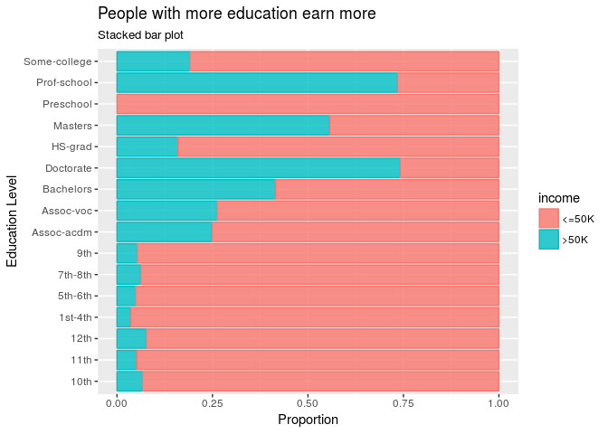

```r
ggplot(dataset, aes(x = education, fill = income, color = income)) +
   geom_bar(alpha = 0.8, position = "fill") +
   coord_flip() +
   labs(x = "Education Level", y = "Proportion", title = "People with more education earn more",
        subtitle = "Stacked bar plot")
```

```r
prop.table(table(dataset$education, dataset$income), 1) * 100
```

```
##
##                     <=50K       >50K
##   10th          93.354770   6.645230
##   11th          94.893617   5.106383
##   12th          92.378753   7.621247
##   1st-4th       96.428571   3.571429
##   5th-6th       95.195195   4.804805
##   7th-8th       93.808050   6.191950
##   9th           94.747082   5.252918
##   Assoc-acdm    75.164011  24.835989
##   Assoc-voc     73.878437  26.121563
##   Bachelors     58.524743  41.475257
##   Doctorate     25.907990  74.092010
##   HS-grad       84.049138  15.950862
##   Masters       44.341265  55.658735
##   Preschool    100.000000   0.000000
##   Prof-school   26.562500  73.437500
##   Some-college  80.976546  19.023454
```

We can see a strong income bias: `Doctorate` > `Masters` > `Bacharelors`. So, the more the person is educated, the greater the probability to earn above 50K.

### Hypothesis 4: Married people tend to earn more

Let’s do the same thing considering now the marital status:

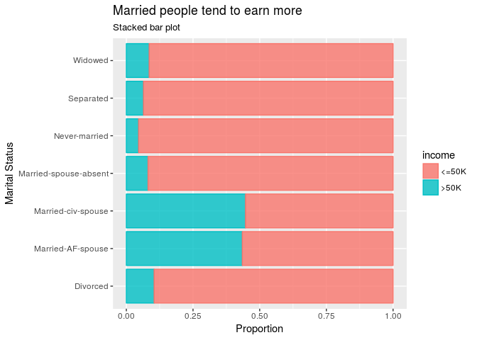

```r
ggplot(dataset, aes(x = marital.status, fill = income, color = income)) +
   geom_bar(alpha = 0.8, position = "fill") +
   coord_flip() +
   labs(x = "Marital Status", y = "Proportion", title = "Married people tend to earn more",
        subtitle = "Stacked bar plot")
```

```r
prop.table(table(dataset$marital.status, dataset$income), 1) * 100
```

```
##
##                             <=50K      >50K
##   Divorced              89.579113 10.420887
##   Married-AF-spouse     56.521739 43.478261
##   Married-civ-spouse    55.315171 44.684829
##   Married-spouse-absent 91.866029  8.133971
##   Never-married         95.403913  4.596087
##   Separated             93.560976  6.439024
##   Widowed               91.440081  8.559919
```

Wee can see that people who are married earn better as compared to people who are single.

### Hypothesis 5: There is a bias in income based on race

Let’s see how earning power is based on the race of the person:

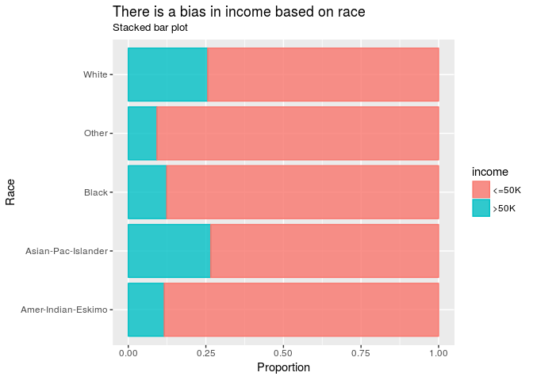

```r
ggplot(dataset, aes(x = race, fill = income, color = income)) +
   geom_bar(alpha = 0.8, position = "fill") +
   coord_flip() +
   labs(x = "Race", y = "Proportion", title = "There is a bias in income based on race",
        subtitle = "Stacked bar plot")
```

```r
prop.table(table(dataset$race, dataset$income), 1) * 100
```

```
##
##                          <=50K      >50K
##   Amer-Indian-Eskimo 88.424437 11.575563
##   Asian-Pac-Islander 73.435996 26.564004
##   Black              87.612036 12.387964
##   Other              90.774908  9.225092
##   White              74.414006 25.585994
```

Asian Pacific people and Whites have the highest earning power.